# Spatial Data in R: New Directions

Edzer Pebesma

Jul 4, 2017, UseR! tutorial

## A short history of handling spatial data in R

- pre-2003: several people doing spatial statistics or map manipulation with S-Plus, and later R (e.g. spatial in MASS; spatstat, maptools, geoR, splancs, gstat, …)
- 2003: workshop at [DSC](https://www.r-project.org/conferences/DSC-2003/), agreement that a package with base classes would be useful
- 2003: start of r-sig-geo
- 2003: rgdal released on CRAN
- 2005: sp released on CRAN
- 2008: [Applied Spatial Data Analysis with R](http://www.asdar-book.org/)
- 2011: rgeos released on CRAN
- 2013: second edition of [Applied Spatial Data Analysis with R](http://www.asdar-book.org/)
- 2016-7: [simple features for R](https://cran.r-project.org/package=sf), R consortium support
- 2017-8: [spatiotemporal tidy arrays for R](https://github.com/edzer/stars), R consortium support

## Simple feature access in R: package `sf`

Simple feature access is an [ISO standard](http://www.opengeospatial.org/standards/sfa).

What is this about?

- *feature*: abstraction of real world phenomena (type, or instance)
- *simple feature*: feature with all geometric attributes described piecewise by straight line or planar interpolation between sets of points
- 7 + 10 [types](https://en.wikipedia.org/wiki/Well-known_text#Well-known_binary), 68 classes, of which 7 used in like 99% of the use cases
- support for mixed type (`GEOMETRYCOLLECTION`), and type mix (`GEOMETRY`)
- empty geometry (like `NA`)

```r
library(sf)
## Linking to GEOS 3.5.1, GDAL 2.1.3, proj.4 4.9.2, lwgeom 2.3.2 r15302
```

links to [GEOS](https://trac.osgeo.org/geos/), [GDAL](http://www.gdal.org/), [Proj.4](http://proj4.org/), liblwgeom

*access* refers to standardised encodings, such as well-known text (WKT):

```r
(pt = st_point(c(2,4)))
## POINT(2 4)
```

and well-known binary,

```r
(pt_bin = st_as_binary(pt))
```

```
##  [1] 01 01 00 00 00 00 00 00 00 00 00 00 40 00 00 00 00 00 00 10 40
```

the binary form in which spatial databases put geometries in BLOBs, binary large objects, converted back by

```r
st_as_sfc(list(pt_bin))[[1]]
## POINT(2 4)
```

as well as to *names* of functions to manipulate objects, e.g.

```r
st_dimension(pt)
```

```
## [1] 0
```

```r
st_intersects(pt, pt, sparse = FALSE)
```

```
##      [,1]
## [1,] TRUE
```

package `sf` uses simple R structures to store geometries:

```r
str(pt)
```

```
## Classes 'XY', 'POINT', 'sfg'  num [1:2] 2 4
```

```r
str(st_linestring(rbind(c(0,0), c(0,1), c(1,1))))
```

```
##  XY [1:3, 1:2] 0 0 1 0 1 1
```

```r
str(st_polygon(list(rbind(c(0,0), c(0,1), c(1,1), c(0,0)))))
```

```
## List of 1
##  $ : num [1:4, 1:2] 0 0 1 0 0 1 1 0
##  - attr(*, "class")= chr [1:3] "XY" "POLYGON" "sfg"
```

## Tidyverse, list-columns

According to the “tidy data” paper ([Wickham 2014](https://www.jstatsoft.org/article/view/v059i10)), data is tidy when

1. Each variable forms a column.
2. Each observation forms a row.
3. Each type of observational unit forms a table.

but it is not directly clear how this maps to geometries: should a coordinate dimension (e.g. latitude) for a column, should each coordinate (x,y pair) form a colum, or should a whole geometry (e.g. polygon, with holes), form a column? Early attempts (and ggplot2 up to version 2.2.1) wanted *simple* columns, meaning each coordinate split over two columns. An approach called *fortify* would mold (tidy?) polygons into simple `data.frame`s. It is [well known](https://github.com/tidyverse/ggplot2/wiki/plotting-polygon-shapefiles) that this approach has its limitations when polygons have holes.

During the [UseR! 2016 keynote](https://channel9.msdn.com/Events/useR-international-R-User-conference/useR2016/Towards-a-grammar-of-interactive-graphics) of Hadley, list-columns have become tidy. One of the arguments for this was exactly this: polygons with holes are hard to represent in simple `data.frame`s. Other cases are: nested `data.frame`s, or columns that contain, for each record, a model object e.g. obtained from `lm`.

The tidy data rule for simple feature means: we have a `data.frame` **where each *feature* forms a row**. A single column (a list-column) contains the geometry for each observation.

Package `sf` puts geometries in a list-column of class `sfc`, where each list element is a feature geometry of class `sfg`. Feature geometries are represented in R by

- a numeric vector for a single point (`POINT`)
- a numeric matrix (each row a point) for a set of points (`MULTIPOINT` or `LINESTRING`)
- a list of matrices for a set of set of points (`MULTIINESTRING`, `POLYGON`)
- a list of lists of matrices (`MULTIPOLYGON`)
- a list of anything mentioned above (`GEOMETRYCOLLECTION`)

(all other classes also fall in one of these categories)

Other tidy aspects of `sf`:

- all functions/methods start with `st_`, use tab completion to search
- `read_sf` is an alias for `st_read` with tidyverse defaults: silent, `stringAsFactors = FALSE`
- all function have data as first argument, “pipe-friendly”
- many tidy verbs implemented as methods for `sf` objects (see further down)

## Reference systems

Coordinates of geospatial data need a reference system:

- geodesic/geographic coordinates need an order (long/lat or lat/long?), a unit (rad, degree?) and a datum (a reference ellipsoid: WGS84, ETRS89, NAD27?)
- projected coordinates (e.g. UTM, web Mercator) need also measurement units, and some way of encoding how they relate to geodesic coordinates, in which datum (the Proj.4 string)

Package `sf` has `crs` objects that register coordinate reference systems:

```r
st_crs("+proj=longlat +datum=WGS84")
```

```
## $epsg
## [1] 4326
##
## $proj4string
## [1] "+proj=longlat +datum=WGS84 +no_defs"
##
## attr(,"class")
## [1] "crs"
```

```r
st_crs(3857)
```

```
## $epsg
## [1] 3857
##
## $proj4string
## [1] "+proj=merc +a=6378137 +b=6378137 +lat_ts=0.0 +lon_0=0.0 +x_0=0.0 +y_0=0 +k=1.0 +units=m +nadgrids=@null +wktext +no_defs"
##
## attr(,"class")
## [1] "crs"
```

```r
st_crs(NA)
```

```
## $epsg
## [1] NA
##
## $proj4string
## [1] NA
##
## attr(,"class")
## [1] "crs"
```

`crs` objects are registered as an attribute of geometry collections.

## sf: handling real data

### reading and writing spatial data

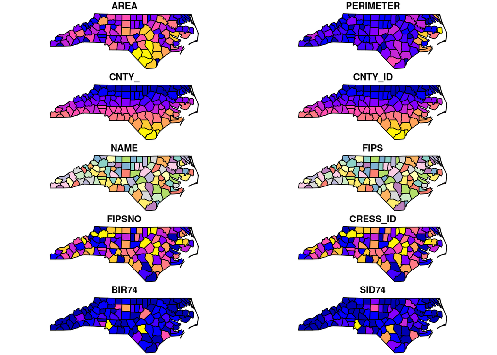

```r
fname = system.file("shape/nc.shp", package = "sf")
nc = read_sf(fname)
print(nc, n = 3)
## Simple feature collection with 100 features and 14 fields
## geometry type:  MULTIPOLYGON
## dimension:      XY
## bbox:           xmin: -84.32385 ymin: 33.88199 xmax: -75.45698 ymax: 36.58965
## epsg (SRID):    4267
## proj4string:    +proj=longlat +datum=NAD27 +no_defs
## First 3 features:
##    AREA PERIMETER CNTY_ CNTY_ID      NAME  FIPS FIPSNO CRESS_ID BIR74
## 1 0.114     1.442  1825    1825      Ashe 37009  37009        5  1091
## 2 0.061     1.231  1827    1827 Alleghany 37005  37005        3   487
## 3 0.143     1.630  1828    1828     Surry 37171  37171       86  3188
##   SID74 NWBIR74 BIR79 SID79 NWBIR79                       geometry
## 1     1      10  1364     0      19 MULTIPOLYGON(((-81.47275543...
## 2     0      10   542     3      12 MULTIPOLYGON(((-81.23989105...
## 3     5     208  3616     6     260 MULTIPOLYGON(((-80.45634460...
plot(nc)
```

## Methods for simple features

A complete list of methods for a particular class is obtained, after loading the class, by

```r
methods(class = "sf")
```

### book keeping, low-level I/O:

- `st_as_text`: convert to WKT
- `st_as_binary`: convert to WKB
- `st_as_sfc`: convert geometries to `sfc` (e.g., from WKT, WKB)
- `as(x, "Spatial")`: convert to `Spatial*`
- `st_as_sf`: convert to sf (e.g., convert from `Spatial*`)

### coordinate transformation/conversion

- `st_transform`: transforms or converts coordinates to new reference system

```r
(a1 = st_area(nc[1,]))                      # area, using geosphere::areaPolygon
## 1137388604 m^2
(a2 = st_area(st_transform(nc[1,], 32119))) # NC state plane, m
## 1137598162 m^2
(a3 = st_area(st_transform(nc[1,], 2264)))  # NC state plane, US foot
## 12244955726 US_survey_foot^2
units::set_units(a1, km^2)
## 1137.389 km^2
units::set_units(a2, km^2)
## 1137.598 km^2
units::set_units(a3, km^2)
## 1137.598 km^2
```

### logical binary geometry predicates

- `st_intersects`: touch or overlap
- `st_disjoint`: !intersects
- `st_touches`: touch
- `st_crosses`: cross (don’t touch)
- `st_within`: within
- `st_contains`: contains
- `st_overlaps`: overlaps
- `st_covers`: cover
- `st_covered_by`: covered by
- `st_equals`: equals
- `st_equals_exact`: equals, with some fuzz

returns a sparse (default) or dense logical matrix:

```r
nc1 = nc[1:5,]
st_intersects(nc1, nc1)
## although coordinates are longitude/latitude, it is assumed that they are planar
## [[1]]
## [1] 1 2
##
## [[2]]
## [1] 1 2 3
##
## [[3]]
## [1] 2 3
##
## [[4]]
## [1] 4
##
## [[5]]
## [1] 5
st_intersects(nc1, nc1, sparse = FALSE)
## although coordinates are longitude/latitude, it is assumed that they are planar
##       [,1]  [,2]  [,3]  [,4]  [,5]
## [1,]  TRUE  TRUE FALSE FALSE FALSE
## [2,]  TRUE  TRUE  TRUE FALSE FALSE
## [3,] FALSE  TRUE  TRUE FALSE FALSE
## [4,] FALSE FALSE FALSE  TRUE FALSE
## [5,] FALSE FALSE FALSE FALSE  TRUE
```

### geometry generating logical operators

- `st_union`: union of several geometries
- `st_intersection`: intersection of pairs of geometries
- `st_difference`: difference between pairs of geometries
- `st_sym_difference`: symmetric difference (`xor`)

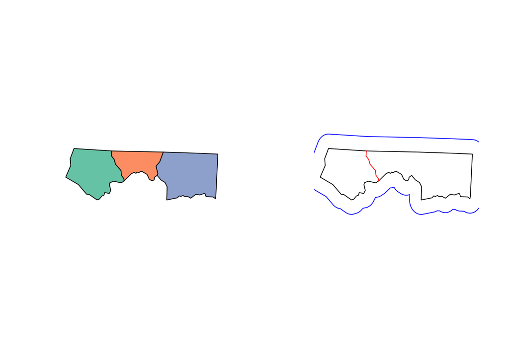

```r
opar = par(mfrow = c(1,2))
ncg = st_geometry(nc[1:3,])
plot(ncg, col = sf.colors(3, categorical = TRUE))
u = st_union(ncg)
plot(u)
plot(st_intersection(ncg[1], ncg[2]), col = 'red', add = TRUE)
plot(st_buffer(u, 0.1), border = 'blue', add = TRUE)
```

```r
par(opar)
```

### higher-level operations using these:

- `aggregate`, `summarise`: unions (by default) grouped geometries
- `st_interpolate_aw` for area-weighted interpolation

```r
g = st_make_grid(nc, n = c(20,10))
a1 = st_interpolate_aw(nc["BIR74"], g, extensive = FALSE)
sum(a1$BIR74) / sum(nc$BIR74) # not close to one: property is assumed spatially intensive
```

```
## [1] 1.20742
```

```r
a2 = st_interpolate_aw(nc["BIR74"], g, extensive = TRUE)
sum(a2$BIR74) / sum(nc$BIR74)
```

```
## [1] 1.000013
```

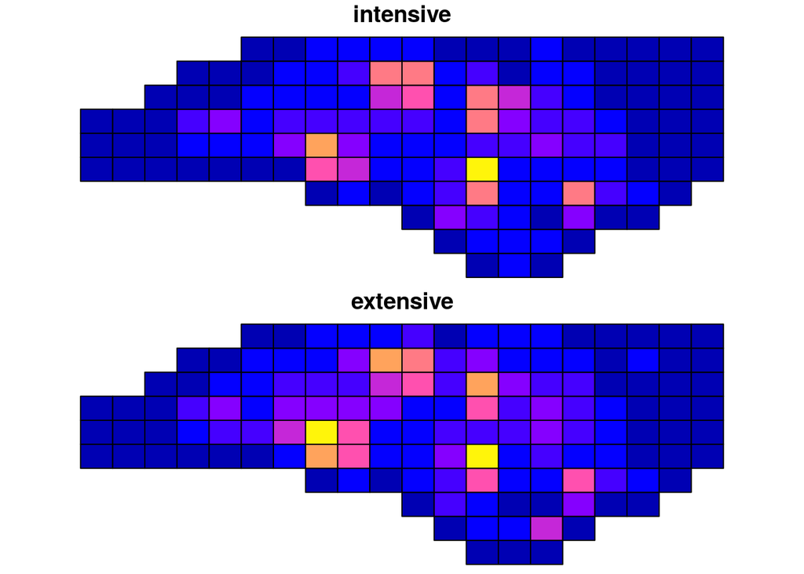

```r
a1$intensive = a1$BIR74
a1$extensive = a2$BIR74
plot(a1[c("intensive", "extensive")])
```

### manipulating geometries:

- `st_line_merge`: merges lines
- `st_segmentize`: adds points to straight lines
- `st_voronoi`: creates voronoi tesselation
- `st_centroid`: gives centroid of geometry
- `st_convex_hull`: creates convex hull of set of points
- `st_triangulate`: triangulates set of points (not constrained)
- `st_polygonize`: creates polygon from lines that form a closed ring
- `st_simplify`: simplifies lines by removing vertices
- `st_split`: split a polygon given line geometry
- `st_buffer`: compute a buffer around this geometry/each geometry
- `st_make_valid`: tries to make an invalid geometry valid (requires lwgeom)
- `st_boundary`: return the boundary of a geometry

### convenience functions:

- `st_zm`: sets or removes z and/or m geometry
- `st_coordinates`: retrieve coordinates in a matrix or data.frame
- `st_geometry`: set, or retrieve `sfc` from an `sf` object
- `st_is`: check whether geometry is of a particular type

### handling mixes: `GEOMETRY`, `GEOMETRYCOLLECTION`

### empty geometries

operations on sets: `st_cast`

- `st_cast` without arguments: unravels a `geometrycollection`, converts X + multiX sets into sets of multiX

Three main classes: * `sf`: subclass of `data.frame` or tibble, containing at least one list-columns of class `sfc` * `sfc`: simple feature geometry list-column, carries `bbox` and `crs` as attributes, list elements are of class `sfg` * `sfg`: geometry of a *single* feature; element of an `sfc` list-column

## Coordinate reference systems, and where to put them

## Pipe-based workflows and tidyverse

When *both* `sf` and `dplyr` are loaded, a number of `dplyr` generic methods become available for `sf` objects. They are:

```r
m1 = attr(methods(class = "sf"), "info")$generic
suppressPackageStartupMessages(library(dplyr))
m2 = attr(methods(class = "sf"), "info")$generic
noquote(grep("_$", setdiff(m2, m1), invert = TRUE, value = TRUE))
```

```
##  [1] anti_join   arrange     distinct    filter      full_join
##  [6] group_by    inner_join  left_join   mutate      rename
## [11] right_join  sample_frac sample_n    select      semi_join
## [16] slice       summarise   transmute   ungroup
```

Most of these do little more than simply make sure the returned object is of class `sf` again, but some of them do more, e.g. `summarise` by default aggregates (unions) the summarised geometries:

```r
nc <- read_sf(system.file("shape/nc.shp", package="sf"))
cent <- st_geometry(nc) %>% st_centroid %>% st_coordinates
```

[output not shown]

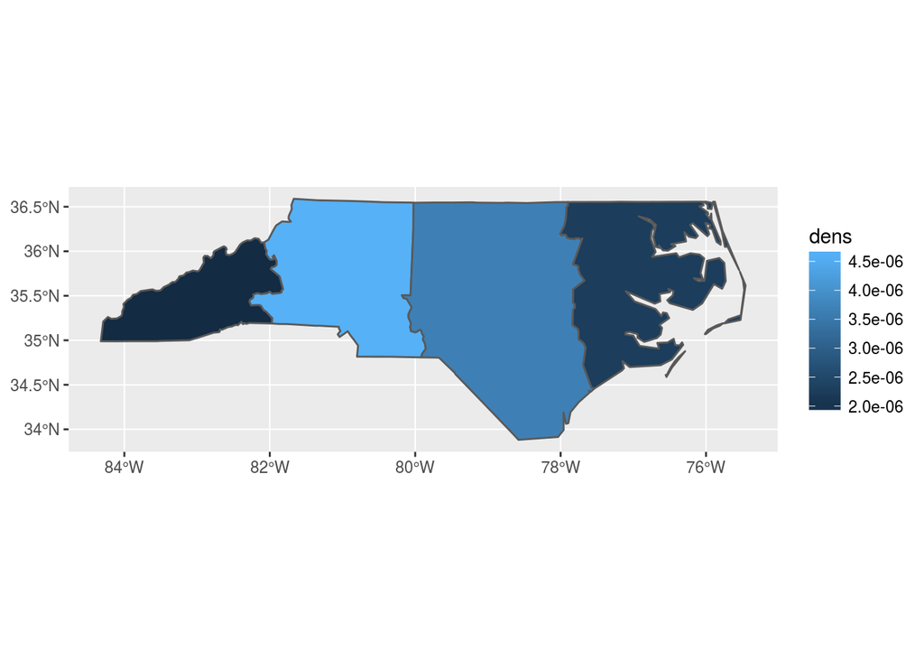

```r
nc1 <- nc %>% mutate(area = as.numeric(st_area(.)), longitude = cent[,1]) %>%
  group_by(cut(longitude,4))  %>%
  summarise(area = sum(area), BIR79 = sum(BIR79), dens = mean(BIR79/area))
# devtools::install_github("tidyverse/ggplot2")
library(ggplot2)
ggplot(nc1) + geom_sf(aes(fill = dens))
```

## Array data: rasters, spatial time series

## Summary/outlook

In comparison to `sp`, package `sf`

- implements all types and classes of simple features
- has no support for gridded (raster) data
- uses `data.frame`s for features, and list columns for feature geometry
- uses S3 instead of S4
- is also built on top of GDAL, GEOS and Proj.4
- tries to provide a simpler and cleaner API (or user experience) conversions to/from `sp` makes it still easy to work “backwards”

What’s really new, and better in `sf`, compared to `sp`?

- simple features is a widely adopted standard
- tidyverse compatibility
- ggplot2 support (`install_github`, under development)
- support by mapview, tmap, mapedit
- binary geom ops: fast, low memory footprint; flexible `st_join`
- (c)lean Rcpp interface to external dependencies GDAL/GEOS/Proj.4
- fast WKB I/O, written in C++

Still to do (no promises):

- time series for simple features
- raster data, raster-sf integration stars - see my UseR! talk
- scale from in-memory to in-database with spatial operations, similar to what `dplyr` does